# Project Foundations for Data Science: FoodHub Data Analysis

**Marks: 40**

### Context

The number of restaurants in New York is increasing day by day. Lots of students and busy professionals rely on those restaurants due to their hectic lifestyles. Online food delivery service is a great option for them. It provides them with good food from their favorite restaurants. A food aggregator company FoodHub offers access to multiple restaurants through a single smartphone app.

The app allows the restaurants to receive a direct online order from a customer. The app assigns a delivery person from the company to pick up the order after it is confirmed by the restaurant. The delivery person then uses the map to reach the restaurant and waits for the food package. Once the food package is handed over to the delivery person, he/she confirms the pick-up in the app and travels to the customer's location to deliver the food. The delivery person confirms the drop-off in the app after delivering the food package to the customer. The customer can rate the order in the app. The food aggregator earns money by collecting a fixed margin of the delivery order from the restaurants.

### Objective

The food aggregator company has stored the data of the different orders made by the registered customers in their online portal. They want to analyze the data to get a fair idea about the demand of different restaurants which will help them in enhancing their customer experience. Suppose you are hired as a Data Scientist in this company and the Data Science team has shared some of the key questions that need to be answered. Perform the data analysis to find answers to these questions that will help the company to improve the business.

### Data Description

The data contains the different data related to a food order. The detailed data dictionary is given below.

### Data Dictionary

- order_id: Unique ID of the order
- customer_id: ID of the customer who ordered the food
- restaurant_name: Name of the restaurant
- cuisine_type: Cuisine ordered by the customer
- cost: Cost of the order
- day_of_the_week: Indicates whether the order is placed on a weekday or weekend (The weekday is from Monday to Friday and the weekend is Saturday and Sunday)
- rating: Rating given by the customer out of 5
- food_preparation_time: Time (in minutes) taken by the restaurant to prepare the food. This is calculated by taking the difference between the timestamps of the restaurant's order confirmation and the delivery person's pick-up confirmation.
- delivery_time: Time (in minutes) taken by the delivery person to deliver the food package. This is calculated by taking the difference between the timestamps of the delivery person's pick-up confirmation and drop-off information

### Let us start by importing the required libraries

```python
# import libraries for data manipulation
import numpy as np
import pandas as pd
import scipy.stats as stats

# import libraries for data visualization
import matplotlib.pyplot as plt
import seaborn as sns

# import library to supress warnings (I have packages running at older versions. This to supress those warnings)
import warnings
```

```python
%matplotlib inline
#Command to display plots
sns.set(style="whitegrid") #Command to display grid lines on plots for readability
#sns.color_palette('dark')
warnings.simplefilter('ignore')# ignore warnings
```

### Understanding the structure of the data

```python
# uncomment and run the following lines for Google Colab
# from google.colab import drive
# drive.mount('/content/drive')
# I work in Jupyter Notebook
```

```python
# read the data
df = pd.read_csv('foodhub_order.csv')
# returns the first 5 rows
df.head()
```

|  | order_id | customer_id | restaurant_name | cuisine_type | cost_of_the_order | day_of_the_week | rating | food_preparation_time | delivery_time |
| --- | --- | --- | --- | --- | --- | --- | --- | --- | --- |
| 0 | 1477147 | 337525 | Hangawi | Korean | 30.75 | Weekend | Not given | 25 | 20 |
| 1 | 1477685 | 358141 | Blue Ribbon Sushi Izakaya | Japanese | 12.08 | Weekend | Not given | 25 | 23 |
| 2 | 1477070 | 66393 | Cafe Habana | Mexican | 12.23 | Weekday | 5 | 23 | 28 |
| 3 | 1477334 | 106968 | Blue Ribbon Fried Chicken | American | 29.20 | Weekend | 3 | 25 | 15 |
| 4 | 1478249 | 76942 | Dirty Bird to Go | American | 11.59 | Weekday | 4 | 25 | 24 |

#### Observations:

The DataFrame has 9 columns as mentioned in the Data Dictionary. Data in each row corresponds to the order placed by a customer.

### **Question 1:** How many rows and columns are present in the data?

```python
# Write your code here
df.shape
```

```
(1898, 9)
```

#### Observations:

The dataset is made of 1898 rows and 9 columns.

### **Question 2:** What are the datatypes of the different columns in the dataset? (The info() function can be used)

```python
# Use info() to print a concise summary of the DataFrame
df.info()
```

```
<class 'pandas.core.frame.DataFrame'>
RangeIndex: 1898 entries, 0 to 1897
Data columns (total 9 columns):
 #   Column                 Non-Null Count  Dtype
---  ------                 --------------  -----
 0   order_id               1898 non-null   int64
 1   customer_id            1898 non-null   int64
 2   restaurant_name        1898 non-null   object
 3   cuisine_type           1898 non-null   object
 4   cost_of_the_order      1898 non-null   float64
 5   day_of_the_week        1898 non-null   object
 6   rating                 1898 non-null   object
 7   food_preparation_time  1898 non-null   int64
 8   delivery_time          1898 non-null   int64
dtypes: float64(1), int64(4), object(4)
memory usage: 133.6+ KB
```

#### Observations:

The dataset is made of 3 data types:

- 4 columns of int64 data type
  - order_id, customer_id, food_preparation_time, delivery_time
- 1 column of float64 data type
  - cost_of_the_order
- 4 columns of object data type
  - restaurant_name, cuisine_type, day_of_the_week, rating

### **Question 3:** Are there any missing values in the data? If yes, treat them using an appropriate method

```python
# Write your code here
df.isna().any()
```

```
order_id                 False
customer_id              False
restaurant_name          False
cuisine_type             False
cost_of_the_order        False
day_of_the_week          False
rating                   False
food_preparation_time    False
delivery_time            False
dtype: bool
```

#### Observations:

There are no missing values in the data set.

### **Question 4:** Check the statistical summary of the data. What is the minimum, average, and maximum time it takes for food to be prepared once an order is placed?

```python
# Write your code here
PrepTime_avg = df['food_preparation_time'].mean();
PrepTime_min = df['food_preparation_time'].min();
PrepTime_max = df['food_preparation_time'].max();
print('Average time taken to prepare food:',np.round(PrepTime_avg,2), 'minutes')
print('Minimum time taken to prepare food:',np.round(PrepTime_min,2), 'minutes')
print('Maximum time taken to prepare food:',np.round(PrepTime_max,2), 'minutes')
```

```
Average time taken to prepare food: 27.37 minutes
Minimum time taken to prepare food: 20 minutes
Maximum time taken to prepare food: 35 minutes
```

#### Observations:

Average time taken to prepare food is **27.37 minutes**  
Minimum time taken to prepare food is **20 minutes**  
Maximum time taken to prepare food is **35 minutes**

### **Question 5:** How many orders are not rated?

```python
# Write the code here
df['rating'].value_counts()
```

```
rating
Not given    736
5            588
4            386
3            188
Name: count, dtype: int64
```

#### Observations:

736 orders are not rated.

### Exploratory Data Analysis (EDA)

### **Question 6:** Explore all the variables and provide observations on their distributions. (Generally, histograms, boxplots, countplots, etc. are used for univariate exploration)

```python
# Write the code here
df.describe(include = 'all')
```

|  | order_id | customer_id | restaurant_name | cuisine_type | cost_of_the_order | day_of_the_week | rating | food_preparation_time | delivery_time |
| --- | --- | --- | --- | --- | --- | --- | --- | --- | --- |
| count | 1.898000e+03 | 1898.000000 | 1898 | 1898 | 1898.000000 | 1898 | 1898 | 1898.000000 | 1898.000000 |
| unique | NaN | NaN | 178 | 14 | NaN | 2 | 4 | NaN | NaN |
| top | NaN | NaN | Shake Shack | American | NaN | Weekend | Not given | NaN | NaN |
| freq | NaN | NaN | 219 | 584 | NaN | 1351 | 736 | NaN | NaN |
| mean | 1.477496e+06 | 171168.478398 | NaN | NaN | 16.498851 | NaN | NaN | 27.371970 | 24.161749 |
| std | 5.480497e+02 | 113698.139743 | NaN | NaN | 7.483812 | NaN | NaN | 4.632481 | 4.972637 |
| min | 1.476547e+06 | 1311.000000 | NaN | NaN | 4.470000 | NaN | NaN | 20.000000 | 15.000000 |
| 25% | 1.477021e+06 | 77787.750000 | NaN | NaN | 12.080000 | NaN | NaN | 23.000000 | 20.000000 |
| 50% | 1.477496e+06 | 128600.000000 | NaN | NaN | 14.140000 | NaN | NaN | 27.000000 | 25.000000 |
| 75% | 1.477970e+06 | 270525.000000 | NaN | NaN | 22.297500 | NaN | NaN | 31.000000 | 28.000000 |
| max | 1.478444e+06 | 405334.000000 | NaN | NaN | 35.410000 | NaN | NaN | 35.000000 | 33.000000 |

#### Restaurants

There are a total of 178 restaurants in the data acquired. Majority of the orders are concentrated in the top few restaurants.  
Shake Shack is the most popular restaurant with 219 orders placed, almost 100 greater than second most popular shop, The Meatball Shop.

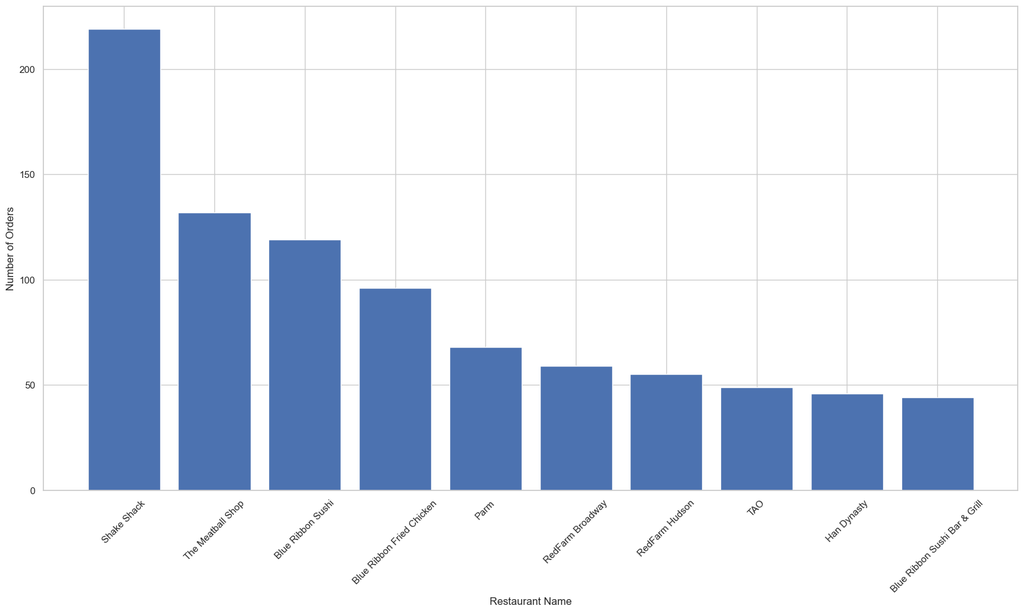

```python
#Analysis of restaurants orders are placed at
#Analysis is performed to find how many orders are placed in each restaurant
#The result is represented as a bar graph
plt.figure(figsize=(20,10));
#Calculate the number of orders for each restaurant
rc=df['restaurant_name'].value_counts()[0:10];#Only display the first 10 for readability
#Plot data as a bar plot
plt.bar(rc.index,rc)
plt.xticks(rotation=45);
plt.xlabel('Restaurant Name');
plt.ylabel('Number of Orders');
```

#### Cuisine Type

Ther are 14 unique cuisine types in the orders placed.  
The most popular cuisine type is American followed by Japanese, Italian and Chinese.  
The least popular cuisine type is Vietnamese.  
Further, majority of the orders are placed on the weekends over the weekdays.

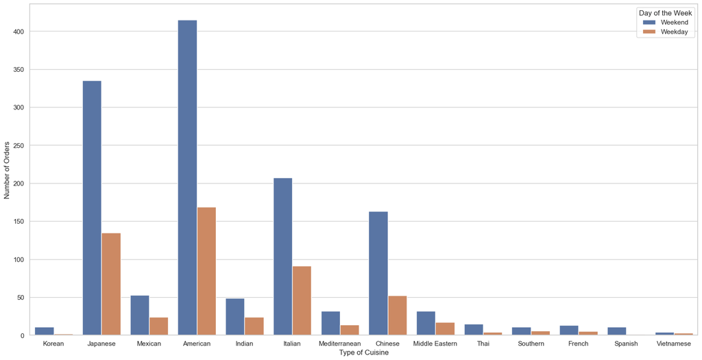

```python
#Analysis of cuisine type orders are placed for
#Analysis is performed to find how many orders are placed for each cuisine
#The result is represented as a bar graph
plt.figure(figsize=(20,10))
sns.countplot(data = df, x='cuisine_type', hue='day_of_the_week');
#The plot is differentiated based on which part of the week the order is placed
plt.xlabel('Type of Cuisine');
plt.ylabel('Number of Orders');
plt.legend(title='Day of the Week');
```

#### Cost of the Order

The costs of the orders range from \$4 to \$35.  
Most of the orders placed are concentrated towards the lower end mainly being less than \$17. Most orders placed cost around \$12 with very few orders above \$25. There are also no orders placed between \$25 to \$30, though that may be attributed to pricing in the restaurants than anything else.  
The orders cost on average \$16 with a median value of \$14. There also is no significant difference between order cost between weekdays and weekends as expected.

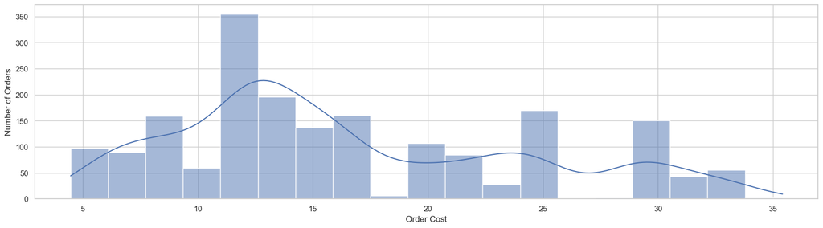

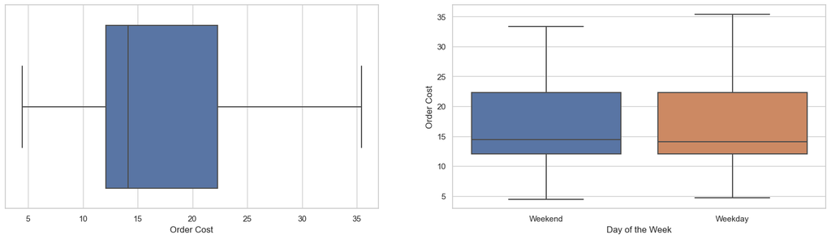

```python
#Analysis of cost of the orders placed
#Analysis is performed to find how many orders are placed for each cost range
#The result is represented as a bar graph
plt.figure(figsize=(20,5))
sns.histplot(data = df, x='cost_of_the_order',kde='True')
plt.xlabel('Order Cost');
plt.ylabel('Number of Orders');

#Analysis is performed to find out the statistiscal spread of cost of the orders
#The result is represented as a box plot
plt.figure(figsize=(20,5))
plt.subplot(121)
sns.boxplot(data = df, x='cost_of_the_order')#Boxplot of the cost of the order
plt.xlabel('Order Cost');
plt.subplot(122)
sns.boxplot(data = df, x='day_of_the_week', y='cost_of_the_order')#Boxplot of the cost of the order based on day of the week
plt.xlabel('Day of the Week');
plt.ylabel('Order Cost');
```

#### Rating

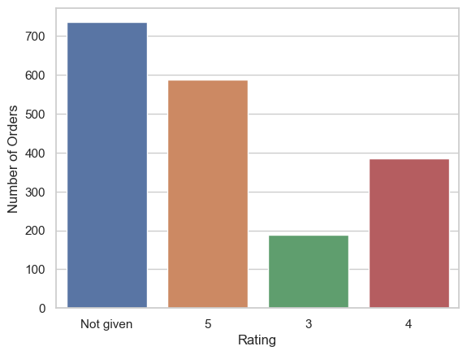

```python
#Analysis of rating given to the orders placed
#Analysis is performed to find how many orders are rated a given value
#The result is represented as a bar graph
sns.countplot(data = df, x='rating');
plt.xlabel('Rating');
plt.ylabel('Number of Orders');
```

#### Day of the Week

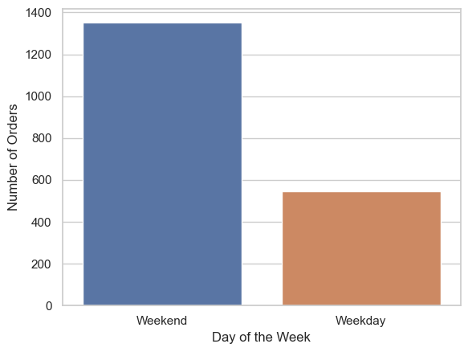

```python
#Analysis of when in a week the orders placed
#Analysis is performed to find how many orders are placed on a weekend as opposed to a weekday
#The result is represented as a bar graph
sns.countplot(data = df, x='day_of_the_week');
plt.xlabel('Day of the Week');
plt.ylabel('Number of Orders');
```

#### Food Preparation Time

It takes anywhere between 20 to 35 minutes to prepare the order with a uniform spread of time taken between the extremes. Though lots of orders are prepared quickly within 20 minutes, the average time to prepare an order is 27 minutes.

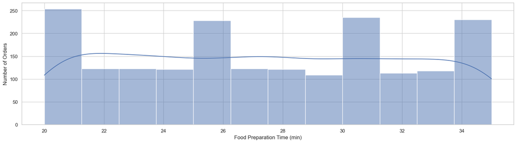

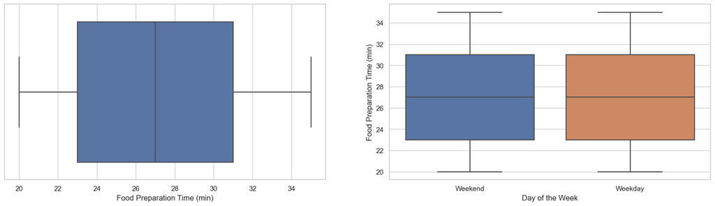

```python
#Analysis of preparation time of the orders placed
#Analysis is performed to find how many orders are placed for each preparation time range
#The result is represented as a bar graph
plt.figure(figsize=(20,5))
sns.histplot(data = df, x='food_preparation_time',kde='True')
plt.xlabel('Food Preparation Time (min)');
plt.ylabel('Number of Orders');

#Analysis is performed to find out the statistiscal spread of preparation time of the orders
#The result is represented as a box plot
plt.figure(figsize=(20,5))
plt.subplot(121)
sns.boxplot(data = df, x='food_preparation_time')
plt.xlabel('Food Preparation Time (min)');
plt.subplot(122)
sns.boxplot(data = df, x='day_of_the_week', y='food_preparation_time')
plt.ylabel('Food Preparation Time (min)');
plt.xlabel('Day of the Week');
```

#### Delivery Time

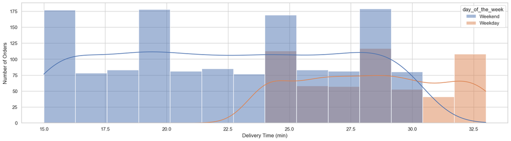

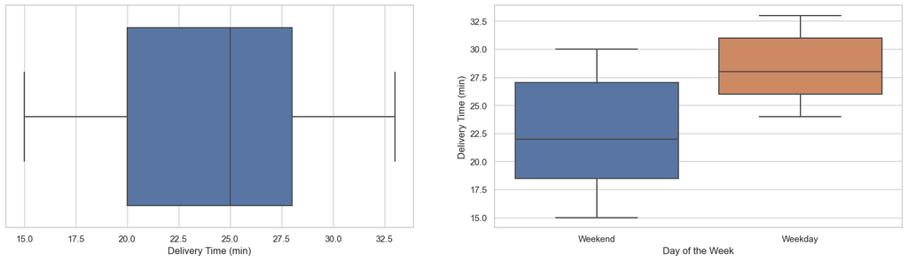

```python
#Analysis of delivery time of the orders placed
#Analysis is performed to find how many orders are placed for each delivery time range
#The result is represented as a bar graph
plt.figure(figsize=(20,5))
sns.histplot(data = df, x='delivery_time',kde='True', hue ='day_of_the_week' )
plt.xlabel('Delivery Time (min)');
plt.ylabel('Number of Orders');

#Analysis is performed to find out the statistiscal spread of delivery time of the orders
#The result is represented as a box plot
plt.figure(figsize=(20,5))
plt.subplot(121)
sns.boxplot(data = df, x='delivery_time')
plt.xlabel('Delivery Time (min)');
plt.subplot(122)
sns.boxplot(data = df, x='day_of_the_week', y='delivery_time')
plt.ylabel('Delivery Time (min)');
plt.xlabel('Day of the Week');
```

### **Question 7**: Which are the top 5 restaurants in terms of the number of orders received?

```python
# Write the code here
df['restaurant_name'].value_counts()[0:5]#Count the number of orders at each restaurant sorted descendingly
```

```
restaurant_name
Shake Shack                  219
The Meatball Shop            132
Blue Ribbon Sushi            119
Blue Ribbon Fried Chicken     96
Parm                          68
Name: count, dtype: int64
```

#### Observations:

Top 5 restaurants are:

1. Shake Shack
2. The Meatball Shop
3. Blue Ribbon Sushi
4. Blue Ribbon Fried Chicken
5. Parm

### **Question 8**: Which is the most popular cuisine on weekends?

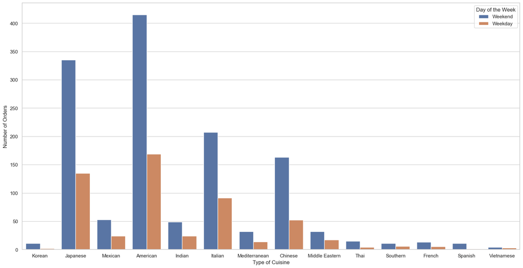

```python
# Write the code here
plt.figure(figsize=(20,10))
sns.countplot(data = df, x='cuisine_type', hue='day_of_the_week');
plt.xlabel('Type of Cuisine');
plt.ylabel('Number of Orders');
plt.legend(title='Day of the Week');
```

#### Observations:

The most popular cuisine on weekends is American.

### **Question 9**: What percentage of the orders cost more than 20 dollars?

```python
# Write the code here
Order20 = df.loc[df['cost_of_the_order']>20]['cost_of_the_order'].count();#Count the number of orders costing more than $20
OrderAll = df['cost_of_the_order'].count();#Count total number of orders
OrderPercent20 = (Order20/OrderAll)*100;#Conver the fraction of orders costing above $20 into percentage
print(np.round(OrderPercent20,2),'% of all orders are above 20$')
```

```
29.24 % of all orders are above 20$
```

#### Observations:

29.24 % of all orders cost more than 20$

### **Question 10**: What is the mean order delivery time?

```python
# Write the code here
DelTime_mean = df['delivery_time'].mean();
print('The mean delivery time is',np.round(DelTime_mean,2),'minutes')
```

```
The mean delivery time is 24.16 minutes
```

### **Question 11:** The company has decided to give 20% discount vouchers to the top 3 most frequent customers. Find the IDs of these customers and the number of orders they placed

```python
# Write the code here
df['customer_id'].value_counts()[0:3]
```

```
customer_id
52832    13
47440    10
83287     9
Name: count, dtype: int64
```

### **Question 12**: Perform a multivariate analysis to explore relationships between the important variables in the dataset. (It is a good idea to explore relations between numerical variables as well as relations between numerical and categorical variables)

#### Cuisine Type

- Most orders placed tend to cost low, around \$10-15, irrespective of the cuisine. Middle Eastern, Thai and Southern cuisine though have a very balanced spread of orders costing anywhere from \$10-30. French and Spanish cuisine are the most expensive costing \$13 for even the most commonly ordered dishes while Vietnamese cuisine is the cheapest costing just \$12 for the most commonly ordered dish.
- All cuisine take around the same time to prepare generally taking aroun 27 minutes to prepare. But there is a good distribution of orders from a quick 20 minutes to a long 32 minutes. Though, Korean generally is prepared much quicker than other cuisines.
- Delivery time also is consistent irrespective of the cuisine ordered with orders taking around 25 minutes to be delivered. French cuisine takes the longest time for orders to be delivered while Korean takes the least. However, the delivery time are affected by traffic conditions, distance travelled and more. So, the analysis here cannot be taken in isolation.

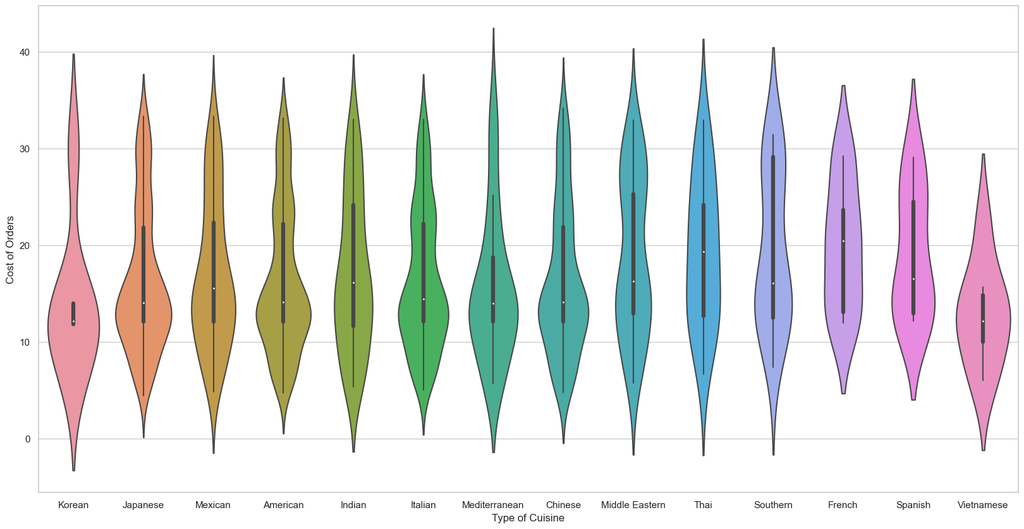

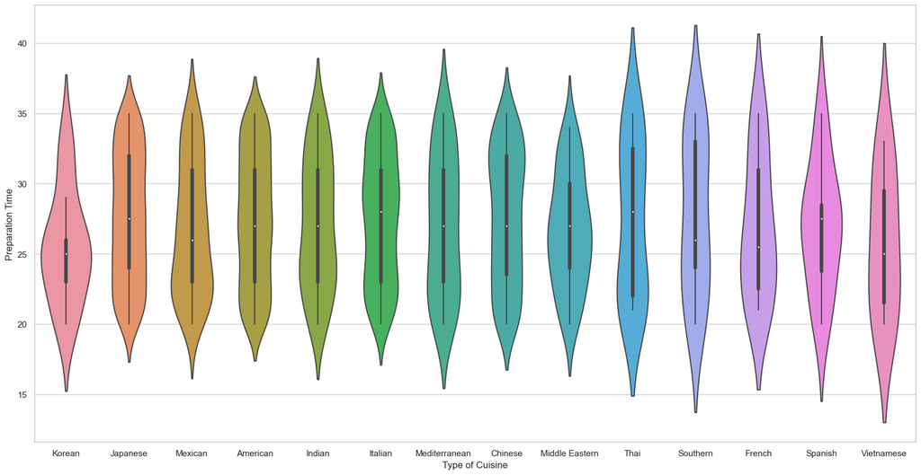

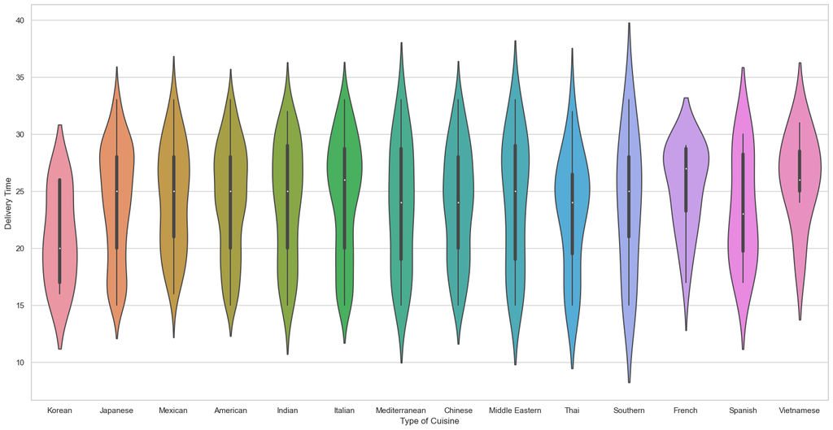

```python
#Analysis of cuisine type orders are placed for
#The result is represented as violin plots

plt.figure(figsize=(20,10))
#Analysis is performed to find cost of the orders that are placed for each cuisine
sns.violinplot(data = df, x='cuisine_type', y='cost_of_the_order')
plt.xlabel('Type of Cuisine');
plt.ylabel('Cost of Orders');

plt.figure(figsize=(20,10))
#Analysis is performed to find preparation time of the orders are placed for each cuisine
sns.violinplot(data = df, x='cuisine_type', y='food_preparation_time')
plt.xlabel('Type of Cuisine');
plt.ylabel('Preparation Time');

plt.figure(figsize=(20,10))
#Analysis is performed to find delivery time of the orders are placed for each cuisine
sns.violinplot(data = df, x='cuisine_type', y='delivery_time')
plt.xlabel('Type of Cuisine');
plt.ylabel('Delivery Time');
```

#### Order Cost

The order cost is not meaningfully related in anyway to the food preparation and delivery time.

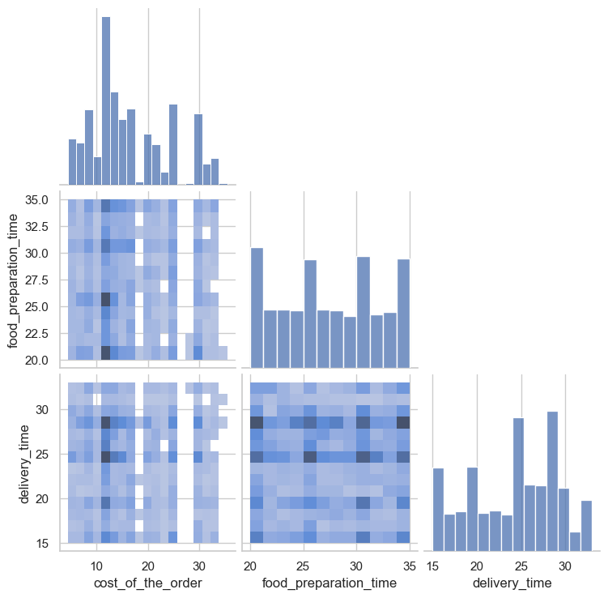

```python
#Analysis of cost of the orders orders as compared to the preparation and delivery time
#The result is represented as scatter plots
sns.pairplot(data=df[['cost_of_the_order','food_preparation_time','delivery_time']], kind = 'hist',corner=True);
```

#### Rating

- All orders are rated nearly similarly irrespective of cost. Orders rated 5 have a slightly higher median value than others showing more expensive orders tend to be rated higher.
- A similar trend is seen with regards to preparation time with orders rated 5 having a slightly higher median value than others. This is not surprising behaviour as these orders have a more expensive median cost and hence take more time to prepare.
- A reversed trend is seen for delivery time with orders rated 4 having a lower median value. This indicates customers probably have lower tolerance for long delivery times with less tasty orders.

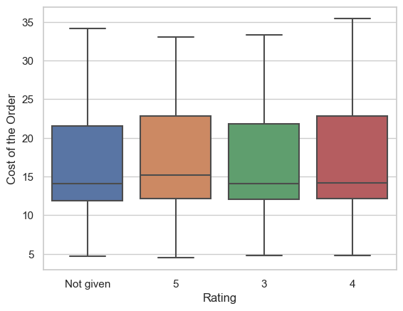

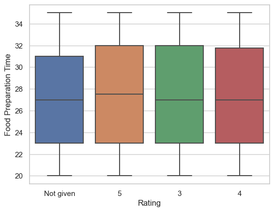

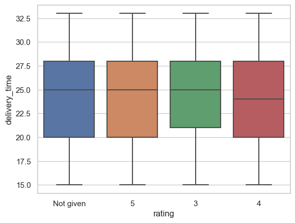

```python
sns.boxplot(data=df, x='rating',y='cost_of_the_order')
plt.xlabel('Rating');
plt.ylabel('Cost of the Order');
plt.figure()
sns.boxplot(data=df, x='rating',y='food_preparation_time')
plt.xlabel('Rating');
plt.ylabel('Food Preparation Time');
plt.figure()
sns.boxplot(data=df, x='rating',y='delivery_time')
```

### **Question 13:** The company wants to provide a promotional offer in the advertisement of the restaurants. The condition to get the offer is that the restaurants must have a rating count of more than 50 and the average rating should be greater than 4. Find the restaurants fulfilling the criteria to get the promotional offer

```python
# Write the code here
df2 = df.copy()#Make a copy of the datadrame to work with
dr = df2.drop(df2.loc[df2['rating'] == 'Not given'].index)#Remove orders that are not rated
drc = dr['restaurant_name'].value_counts();#Count the total number of orders for each restaurant
dr2 = dr.astype({'rating':'int64'})#Convert rating column to integer to perform mean
#dr2.info()
drm = dr2.groupby(['restaurant_name'])['rating'].mean()#Calculate mean of ratings for each restaurant
drm.loc[drc>50]#Find the restaurants that have rating count>50 and mean rating>4
```

```
restaurant_name
Blue Ribbon Fried Chicken    4.328125
Blue Ribbon Sushi            4.219178
Shake Shack                  4.278195
The Meatball Shop            4.511905
Name: rating, dtype: float64
```

#### Observations:

The restaurants fulfilling the conditions to appear in promotional material are:

- Blue Ribbon Fried Chicken
- Blue Ribbon Sushi
- Shake Shack
- The Meatball Shop

### **Question 14:** The company charges the restaurant 25% on the orders having cost greater than 20 dollars and 15% on the orders having cost greater than 5 dollars. Find the net revenue generated by the company across all orders

```python
# Write the code here
#Function charges
##Input:Order cost, int
##Output:Revenue made on order, int
def charges(s):
    if s>20:
        return 0.25*s
    elif s>15:
        return 0.15*s
    else:
        return s
```

```python
df3 = df.copy();#Make a copy of the dataframe to work with
df3['revenue'] = df3['cost_of_the_order'].apply(charges)#Apply the charges function and store the results in a new column
```

```python
#df3.head()
Net_revenue = df3['revenue'].sum();#Calculate total revenue by summing up the revenue column
print('Total revenue made: $',np.round(Net_revenue,2))
```

[output not shown]

### **Question 15:** The company wants to analyze the total time required to deliver the food. What percentage of orders take more than 60 minutes to get delivered from the time the order is placed? (The food has to be prepared and then delivered)

```python
# Write the code here
df4 = df.copy()#Make a copy of the dataframe to work with
#Find total time taken by adding food_preparation_time and delivery_time columns
df4['net_delivery_time'] = df4['food_preparation_time']+df4['delivery_time']
df4.head()
```

|  | order_id | customer_id | restaurant_name | cuisine_type | cost_of_the_order | day_of_the_week | rating | food_preparation_time | delivery_time | net_delivery_time |
| --- | --- | --- | --- | --- | --- | --- | --- | --- | --- | --- |
| 0 | 1477147 | 337525 | Hangawi | Korean | 30.75 | Weekend | Not given | 25 | 20 | 45 |
| 1 | 1477685 | 358141 | Blue Ribbon Sushi Izakaya | Japanese | 12.08 | Weekend | Not given | 25 | 23 | 48 |
| 2 | 1477070 | 66393 | Cafe Habana | Mexican | 12.23 | Weekday | 5 | 23 | 28 | 51 |
| 3 | 1477334 | 106968 | Blue Ribbon Fried Chicken | American | 29.20 | Weekend | 3 | 25 | 15 | 40 |
| 4 | 1478249 | 76942 | Dirty Bird to Go | American | 11.59 | Weekday | 4 | 25 | 24 | 49 |

```python
Long_Deliveries = df4.loc[df4['net_delivery_time']>60]['net_delivery_time'].count();#Find the nummber of deliveries taking longer than 60 minutes
Total_Deliveries = df4['net_delivery_time'].count();#Find the total number of deliveries made
Long_Deliveries_percentage = (Long_Deliveries/Total_Deliveries)*100#Convert to percentage
print(np.round(Long_Deliveries_percentage,2),'% of deliveries are over 60 minutes')
```

```
10.54 % of deliveries are over 60 minutes
```

#### Observations:

10.54% of deliveries are over 60 minutes

### **Question 16:** The company wants to analyze the delivery time of the orders on weekdays and weekends. How does the mean delivery time vary during weekdays and weekends?

```python
# Write the code here
#df.groupby(['day_of_the_week'])['delivery_time'].mean()
Deliveries_Week = df4.groupby(['day_of_the_week'])['net_delivery_time'].mean()
print('Mean delivery time on weekdays is ',np.round(Deliveries_Week[0],2),'minutes')
print('Mean delivery time on weekends is ',np.round(Deliveries_Week[1],2),'minutes')
```

```
Mean delivery time on weekdays is  55.55 minutes
Mean delivery time on weekends is  49.91 minutes
```

#### Observations:

Delivery on weekdays are longer by 5 minutes on average over weekends.

### Recommendations:

- Encouraging customers to rate orders might be helpful in gaining more insight. Perhaps offering some sort of reward (loyalty points or the like) for every order they rate might help.
- Customers predominantly order only a single cuisine type. Encouraging customers to try other cuisine type through discounts and promotional weekends might help generate further revenue.
- Reducing delivery times on weekdays might encourage customers to order on weekdays as well. Providing drivers incentives such as greater pay per order delivered to offset the lower number orders placed might encourage more drivers to operate on weekdays and drive down delivery times.
- Repeated customers should be provided a reward for making multiple orders. A program such as a free meal at a popular restaurant for a certain number of orders will help incentivize customers to keep using the app more regularly.